# Baillon: Weather Forecasts

Quality Assurance - Respondi Data.

Hauke Roggenkamp https://github.com/Howquez (CLICCS)https://www.cliccs.uni-hamburg.de/  
2021-09-15

# Sample Size

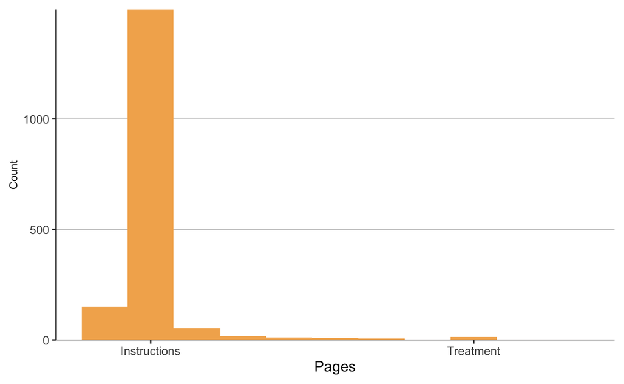

Figure 1: Dropouts by Page.

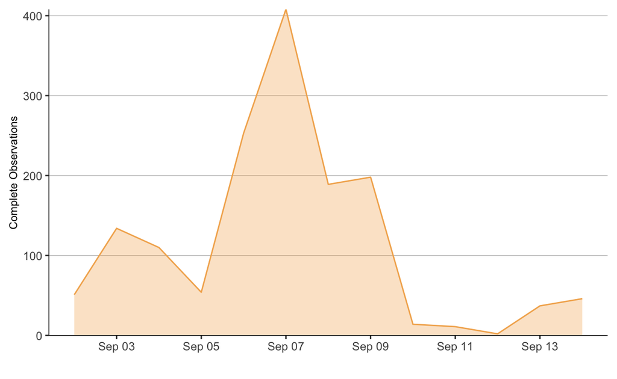

Figure 2: Complete Observations over Time.

1226 participants state that they understood the instructions. 291 say that they did not.[^1]

# Time

The time spent on every decision looks as follows. Intuitively, the pattern makes sense as respondents learn from round 1 to 6. Round 7 exposes the respondents to the forecast, which needs some time to process.

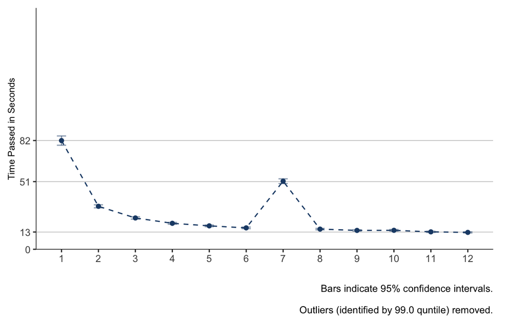

Figure 3: Average Time Spent for each Decision per Round.

The median time to complete the survey was 16 minutes.

# Variance

On an individual level, the data looks as follows.

| participant.label | participant.time_started_utc | ASEP | ACEP | AAI | AGII | treated |
| --- | --- | --- | --- | --- | --- | --- |
| ae5cb5802ca588f73a81e42242d1ae4c | 2021-09-02 10:56:24 | 0.50 | 0.4500000 | 0.0500000 | 1.15 | FALSE |
| 0e379132b6dab27b63921c941312840f | 2021-09-02 11:06:03 | 0.34 | 0.6700000 | -0.0100000 | 0.01 | FALSE |
| 0e379132b6dab27b63921c941312840f | 2021-09-02 11:06:03 | 0.34 | 0.6666667 | -0.0066667 | 0.02 | TRUE |
| ca48f818955f9a22b31d290dc2a28723 | 2021-09-02 11:22:18 | 0.40 | 0.4900000 | 0.1100000 | 0.73 | FALSE |
| ca48f818955f9a22b31d290dc2a28723 | 2021-09-02 11:22:18 | 0.40 | 0.7000000 | -0.1000000 | 0.10 | TRUE |

The reported indices stem from matching probabilities. To check whether respondents stated the matching probabilities diligently, we expect them to exhibit some variance at the individual level. It turns out that there are some people (68) who enter the same matching probability each and every time. The following graph visualizes each respondent’s standard deviation over all 12 rounds as a histogram:

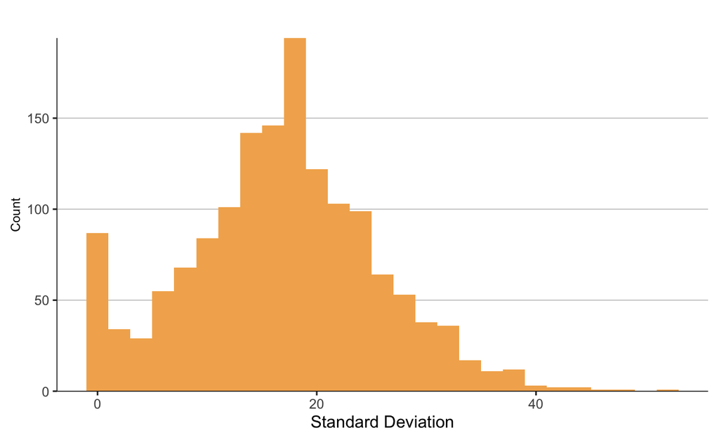

Figure 4: Histogram: Standard Deviation of individual Decisions (across all rounds)

# Treatments

Aggregating these information by treatment yields the following table (where `treated == TRUE` marks Baillon’s indices after participants have seen the forecast).

| location | forecast | treated | Ambiguity Aversion Index | a-insensitivity Index |
| --- | --- | --- | --- | --- |
| Ilomantsi | best_guess | FALSE | -0.0475094 | 0.7205431 |
| Ilomantsi | best_guess | TRUE | -0.0507031 | 0.6997656 |
| Ilomantsi | both | FALSE | -0.0847601 | 0.6912451 |
| Ilomantsi | both | TRUE | -0.1133995 | 0.7051190 |
| Ilomantsi | interval | FALSE | -0.0874214 | 0.6944151 |
| Ilomantsi | interval | TRUE | -0.0846899 | 0.6905039 |
| Weiskirchen | best_guess | FALSE | -0.0624717 | 0.7122453 |
| Weiskirchen | best_guess | TRUE | -0.1010296 | 0.7400772 |
| Weiskirchen | both | FALSE | -0.0951706 | 0.7733071 |
| Weiskirchen | both | TRUE | -0.1033199 | 0.7294779 |
| Weiskirchen | interval | FALSE | -0.0754234 | 0.7330040 |
| Weiskirchen | interval | TRUE | -0.0877322 | 0.7285246 |

The following graph illustrates sample size per treatment arms. Remember that Illomantsi is the surprising treatment group. Technically, the randomization process has not been changed and should work as before.

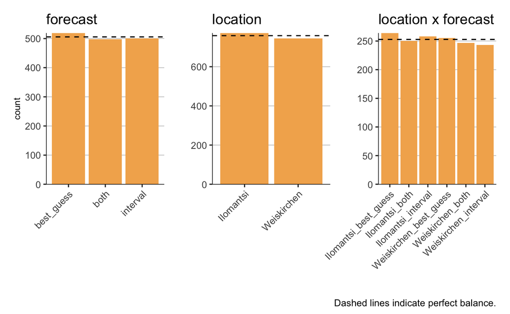

Figure 5: Sample Size by Treatment.

There are some people who drop out after seeing the treatment (18). Let’s see how these dropouts are distributed among treatment arms:

| location | forecast | N |
| --- | --- | --- |
| Ilomantsi | best_guess | 7 |
| Ilomantsi | both | 3 |
| Ilomantsi | interval | 3 |
| Weiskirchen | best_guess | 3 |
| Weiskirchen | both | 1 |
| Weiskirchen | interval | 1 |

| location | forecast | N |
| --- | --- | --- |
| Ilomantsi | best_guess | 1012 |
| Ilomantsi | both | 856 |
| Ilomantsi | interval | 815 |
| Weiskirchen | best_guess | 846 |
| Weiskirchen | both | 826 |
| Weiskirchen | interval | 856 |

# Payoffs

| Participants | Total Bonus Payments | Average Bonus Payment |
| --- | --- | --- |
| 1517 | 8890 | 5.86 |

# Sample Properties

The majority (761 out of 1507 participants) is male. 149 participants have no interest in vaccinations and 1221 are vaccinated (at least once) already. The average participant is 44 years of age.

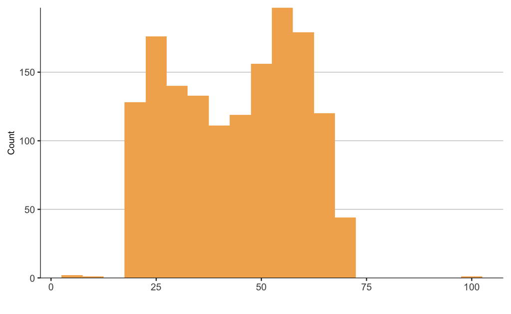

Figure 6: Histogram: Age Distribution.

# Treatment Effects

## Pre-Treatment Indices

[figure not shown]

## Post-Treatment Indices

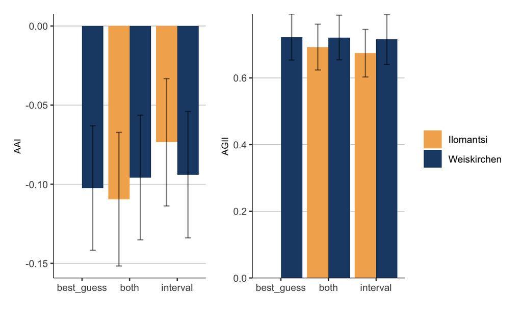

# Reporting

Der aktuelle Stand ist wie folgt: Wir zählen 1517 abgeschlossene Umfragen bei 3279 Einstiegen. Die Abbrecherquote liegt entsprechend bei 53.7%. Der Anteil der Männer liegt bei knapp 50.4% und das Durchschnittsalter beträgt 44 Jahre. Im Median haben die TeilnehmerInnen 16 Minuten gebraucht, um die Studie abzuschließen.

889 (also 58.6%) TeilnehmerInnen haben 10 Euro als sonder-Incentive verdient. Zusammen mit dem fixen Incentive in Höhe von 2 Euro müssen wir dementsprechend 11924 Euro auszahlen.

[^1]: 32 stated that they did not understand the game at all.